# R Basics: Introduction to R

By Anahita Sanandaji

MIS 4580

###### “Copyright 2020 may not be shared or posted without permission.”

[figure not shown]

#### Please make sure to watch the learning activity video.

### 1. What is R?

- R is an open source software
- R is a powerful tool for statistics, data analytics, and visualization.
  - *Facebook*: user behavior analysis
  - *Google*: advertising effectiveness and economic forecasting.
  - *Twitter*: data visualization
  - *Microsoft*: variety of purposes
  - *Uber*: statistical analysis
  - *Airbnb*: scale data science

### 2. Understanding the Console:

The RStudio console is where everything happens. There are four fundamental panes in the console. Please follow the learning activity video to learn more about it. Also feel free to check: [this tutorial](https://dss.princeton.edu/training/RStudio101.pdf)

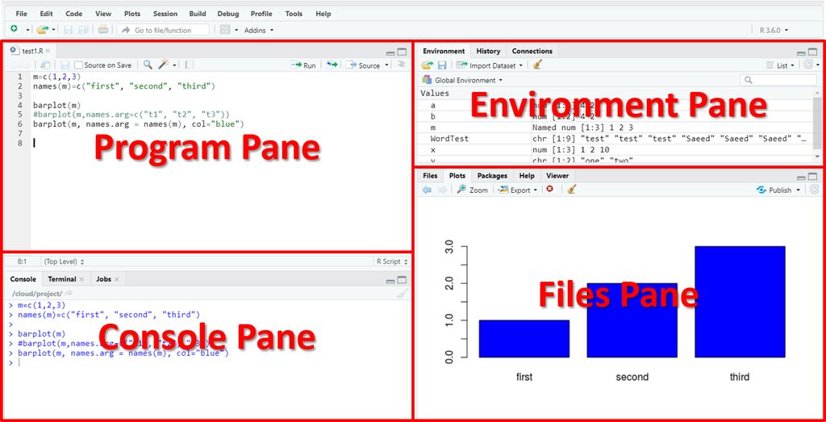

#### 2.1 Program/Script Pane

The top left Pane is where your .R code file will be shown:

- To create a new file you use the **File -> New File menu**.
- To open an existing file you use either the **File -> Open File…** menu or the **Recent Files** menu to select from recently opened files. Feel free to explore this pane while following the learning activity video.

To execute the code in the script editor you have two options:

1. Place the cursor on the line that you would like to execute and execute **Ctrl + Enter**. OR you could hit the **Run** button in the toolbar.
2. If you want to run multiple/all lines of code in the script then you can highlight the lines you want to run and then execute one of the options in #1.

Now try to run your first program. What do you see?

```r
#Write and Run You first Program
2 + 2
```

```
## [1] 4
```

```r
x <- 2

x <- "this is a test"

x
```

```
## [1] "this is a test"
```

#### 2.2 Workspace Environment

The top right pane is the workspace environment which:

1. captures much of your your current R working environment
2. Includes any user-defined objects (vectors, matrices, data frames, lists, functions).

You must be very careful how you save your .R file in the current working directory. getwd() and setwd(“path/to/the/directory”) are the functions for this purpose. We will learn more about it soon.

```r
# returns path for the current working directory
#getwd()

# set the working directory to a specified directory
#setwd("path/to/the/directory")
```

An easier way: Go to **Session -> Set Working Directory -> Choose Directory** and select the directory of choice.

### 3. Get help!

The help documentation and support in R is comprehensive and easily accessible from the command line

```r
# provides general help links
help.start()
```

```
## starting httpd help server ... done
```

```
## If nothing happens, you should open
## 'http://127.0.0.1:26439/doc/html/index.html' yourself
```

```r
# searches the help system matching a given string
help.search("functions")

#provides details for a specific function
help("setwd")
```

And as you know you can always search the web for help. Besides googling, I also use the below resources for help if needed. Feel free to check:

- [Stack Overflow](http://stackoverflow.com/)
- [R-seek](http://rseek.org/)
- [R-bloggers](http://www.r-bloggers.com/)

### 4. Installing & Loading Packages

#### 4.1 Installing Packages

To install packages you typically should use *install.packages(“packageNname”)*. Example: if you want to install the ggplot2 package, which is a very popular visualization package then type the following in the console:

```
# install package from CRAN
install.packages("ggplot2")
```

**Important Note:** if using VDI, you **MUST** install packages every single time you log in to VDI.

#### 4.2 Loading Packages

Once the package is downloaded (e.g., to your computer or VDI) you can access the functions and resources provided by using the command *library(packageName)*:

```r
# load the package to use in the current R session
library(ggplot2)
```

**Important Note:** Unlike *install.packages(“packageNname”)* for *library(packageName)* we do not put packageName inside *“..”*

### 5. Assignment & Evaluation

An important operator you use is the assignment operator. The assignment operator is used to assign a value. For instance we can assign the value 2 to the variable x using the <- assignment operator.

```r
# assignment
x <- 2
x
```

```
## [1] 2
```

R actually allows for five assignment operators:

```r
# leftward assignment
value <- 5
x <- value
x = value
x <<- value

# rightward assignment
value -> x
value ->> x
```

**Note:** for this class I want you to use **<-**. This is the most conventional assignment operator.

We can evaluate the variable “x” by simply typing x at the command line which will return the value of x.

```r
# evaluation
x
```

```
## [1] 5
```

### 6. Be careful about "Case Sensitivity!

R is a case sensitive programming language. This means you **MUST** pay attention to the exact spelling.

```
x <- 1
y <- 3
z <- 4

x * y * z

# this will raise an error why??
x * Y * z
```

### 7. Use of Comments

Note that you can type any comments in your code by preceding the comment with the hash tag (#) symbol. Any values, symbols, and texts following # will not be evaluated.

```r
# this is a comment!
# Assign value 2 to x
x <- 2
```

Organization of your code is very important. It is impossible to decipher thousands of lines of code that has no organization. The easiest way to achieve organization is to comment your code. I expect that your code has some comments.

```r
##################
# Working With R #
##################
#lines of code here...
```

### More Examples: R and Basic Arithmetic